# Practical Machine Learning - Course Project

Kristina Reicher

# Overview

## Background

Using devices such as Jawbone Up, Nike FuelBand, and Fitbit it is now possible to collect a large amount of data about personal activity relatively inexpensively. These type of devices are part of the quantified self movement – a group of enthusiasts who take measurements about themselves regularly to improve their health, to find patterns in their behavior, or because they are tech geeks. One thing that people regularly do is quantify how much of a particular activity they do, but they rarely quantify how well they do it. In this project, your goal will be to use data from accelerometers on the belt, forearm, arm, and dumbell of 6 participants. They were asked to perform barbell lifts correctly and incorrectly in 5 different ways:

- exactly according to the specification (Class A)
- throwing the elbows to the front (Class B)
- lifting the dumbbell only halfway (Class C)
- lowering the dumbbell only halfway (Class D)
- throwing the hips to the front (Class E).

## Data

The training data for this project are available here:

https://d396qusza40orc.cloudfront.net/predmachlearn/pml-training.csv

The test data are available here:

https://d396qusza40orc.cloudfront.net/predmachlearn/pml-testing.csv

The data for this project come from this source: http://web.archive.org/web/20161224072740/http:/groupware.les.inf.puc-rio.br/har.

## Assignment

The goal of this project is to predict the manner in which they did the exercise. This is the “classe” variable in the training set. You may use any of the other variables to predict with. You should create a report describing how you built your model, how you used cross validation, what you think the expected out of sample error is, and why you made the choices you did. You will also use your prediction model to predict 20 different test cases.

# Data Processing

## Loading the data

The data was downloaded from the link above and saved on local computer (in first command for setting working director one can replace loacal file path with path of folder where the data was downloaded). Then it was loaded on the R using the read.csv command.

## Examine the data set

```r
dim(train.raw) #Dimension
```

```
## [1] 19622   160
```

```r
str(train.raw) #Structure
```

```
## 'data.frame':    19622 obs. of  160 variables:
##  $ X                       : int  1 2 3 4 5 6 7 8 9 10 ...
##  $ user_name               : Factor w/ 6 levels "adelmo","carlitos",..: 2 2 2 2 2 2 2 2 2 2 ...
##  $ raw_timestamp_part_1    : int  1323084231 1323084231 1323084231 1323084232 1323084232 1323084232 1323084232 1323084232 1323084232 1323084232 ...
##  $ raw_timestamp_part_2    : int  788290 808298 820366 120339 196328 304277 368296 440390 484323 484434 ...
##  $ cvtd_timestamp          : Factor w/ 20 levels "02/12/2011 13:32",..: 9 9 9 9 9 9 9 9 9 9 ...
##  $ new_window              : Factor w/ 2 levels "no","yes": 1 1 1 1 1 1 1 1 1 1 ...
##  $ num_window              : int  11 11 11 12 12 12 12 12 12 12 ...
##  $ roll_belt               : num  1.41 1.41 1.42 1.48 1.48 1.45 1.42 1.42 1.43 1.45 ...
##  $ pitch_belt              : num  8.07 8.07 8.07 8.05 8.07 8.06 8.09 8.13 8.16 8.17 ...
##  $ yaw_belt                : num  -94.4 -94.4 -94.4 -94.4 -94.4 -94.4 -94.4 -94.4 -94.4 -94.4 ...
##  $ total_accel_belt        : int  3 3 3 3 3 3 3 3 3 3 ...
##  $ kurtosis_roll_belt      : Factor w/ 396 levels "-0.016850","-0.021024",..: NA NA NA NA NA NA NA NA NA NA ...
##  $ kurtosis_picth_belt     : Factor w/ 316 levels "-0.021887","-0.060755",..: NA NA NA NA NA NA NA NA NA NA ...
##  $ kurtosis_yaw_belt       : Factor w/ 1 level "#DIV/0!": NA NA NA NA NA NA NA NA NA NA ...
```

[output cut: 86 more lines]

There is large number of variables that can be considered as ID’s (user_name), or contain row numbers (column X). These variables can not be predictors for quality of exercise. Furthermore, columns containing timestamps and the factors new_window and num_window will not be used because they are not related to the type od exercise. To easy eliminate variables that I choose to ignore from training dataset, I will create a vector of variable names that will not be used in the model.

## Checking for missing values

As we can seen in data examination, there are several variables in all instances that are missing, but I will also remove all variables which have more the 70% of missing values.

```r
vars<-names(train.raw)
missing.values.count<-sapply(train.raw[vars],function(x)sum(is.na(x)))
missing.values.varnames<-names(which(missing.values.count>=0.7*nrow(train.raw))) #removing variables with more than 70% of missings
ignore<-union(ignore,missing.values.varnames)
length(ignore)
```

```
## [1] 107
```

Only those variables that are not put in ignore vector are retained. 107 variables were manually removed.

```r
vars.keep <-setdiff(vars,ignore)
train.clean <- train.raw [,vars.keep]
dim(train.clean) #Dimension
```

```
## [1] 19622    53
```

Training data set now has 53 variables instead of 160 variables that it was having at the beginning of the variable selection process.

# Checking correlations

I am using cor function from caret package to find correlations between the variables and removing variables from training dataset that are high correlated.

Final clean data set with 32 variables left:

```r
train.clean <- train.raw [,vars.keep]
dim(train.clean) #Dimension
```

```
## [1] 19622    32
```

```r
str(train.clean) #Structure
```

```
## 'data.frame':    19622 obs. of  32 variables:
##  $ yaw_belt            : num  -94.4 -94.4 -94.4 -94.4 -94.4 -94.4 -94.4 -94.4 -94.4 -94.4 ...
##  $ gyros_belt_x        : num  0 0.02 0 0.02 0.02 0.02 0.02 0.02 0.02 0.03 ...
##  $ gyros_belt_y        : num  0 0 0 0 0.02 0 0 0 0 0 ...
##  $ gyros_belt_z        : num  -0.02 -0.02 -0.02 -0.03 -0.02 -0.02 -0.02 -0.02 -0.02 0 ...
##  $ magnet_belt_x       : int  -3 -7 -2 -6 -6 0 -4 -2 1 -3 ...
##  $ magnet_belt_y       : int  599 608 600 604 600 603 599 603 602 609 ...
##  $ roll_arm            : num  -128 -128 -128 -128 -128 -128 -128 -128 -128 -128 ...
##  $ pitch_arm           : num  22.5 22.5 22.5 22.1 22.1 22 21.9 21.8 21.7 21.6 ...
##  $ yaw_arm             : num  -161 -161 -161 -161 -161 -161 -161 -161 -161 -161 ...
##  $ total_accel_arm     : int  34 34 34 34 34 34 34 34 34 34 ...
##  $ gyros_arm_y         : num  0 -0.02 -0.02 -0.03 -0.03 -0.03 -0.03 -0.02 -0.03 -0.03 ...
##  $ gyros_arm_z         : num  -0.02 -0.02 -0.02 0.02 0 0 0 0 -0.02 -0.02 ...
##  $ magnet_arm_x        : int  -368 -369 -368 -372 -374 -369 -373 -372 -369 -376 ...
##  $ magnet_arm_z        : int  516 513 513 512 506 513 509 510 518 516 ...
```

[output cut: 18 more lines]

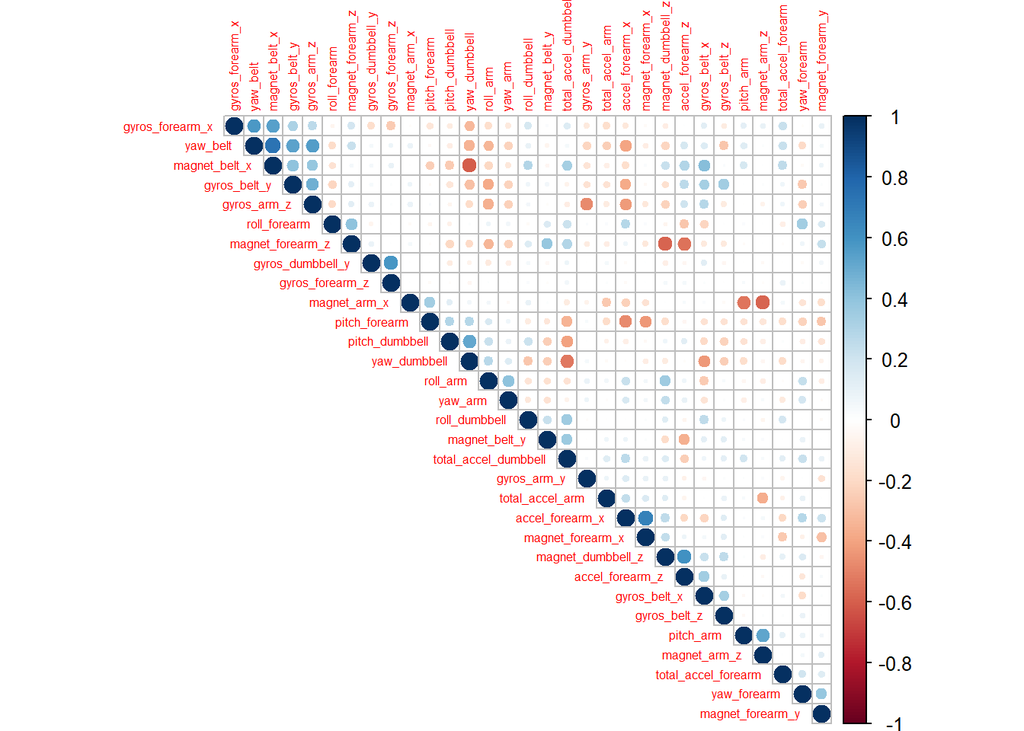

```r
library(corrplot);
correlations <- cor(train.clean[,-c(32)]) #all variables except target variable classe
corrplot(correlations, type = "upper", order = "hclust", tl.cex = 0.5)
```

# Partitioning the training dataset

I will create training and testitng partitions of the data set using the createDataPartition funcition from caret packages. Target variable classe is randomly distributed in training and testing data partition preserving class distribution. 70% od the data is used for model training, and 30% for cross validation testing.

```r
set.seed(100003)
inTrain <- createDataPartition(train.clean$classe, p = 0.7, list = FALSE)
train.data <- train.clean[inTrain, ] # training data set
test.data <- train.clean[-inTrain, ] # testing data set
dim(train.data) #Dimension
```

```
## [1] 13737    32
```

```r
dim(test.data) #Dimension
```

```
## [1] 5885   32
```

# Building model with machine learning algoritm

In this section I will try predict the outcome with 3 different models, using folowing algorithams for model training: 1. classification trees 2. random forest 3. gradient boosting method

First, to prevent overfitting and improve the efficicency of the models, one should define the type of cross-validation which will be used. I will use 5 folds (the number of folds depends on the data size, 5 folds means that 20% of the data is used for testing, and our data sets are large enough. By icreasing number of folds on this data sets we can get higher computational times with no significant increase of the accuracy).

```r
trControl <- trainControl(method="cv", number=5)
```

## Prediction with classification trees

By using the train() function from the caret package for “rpart” model type I will build the first model, and then print calssification tree as a denogram using the fancyRpartPlot() funcition.

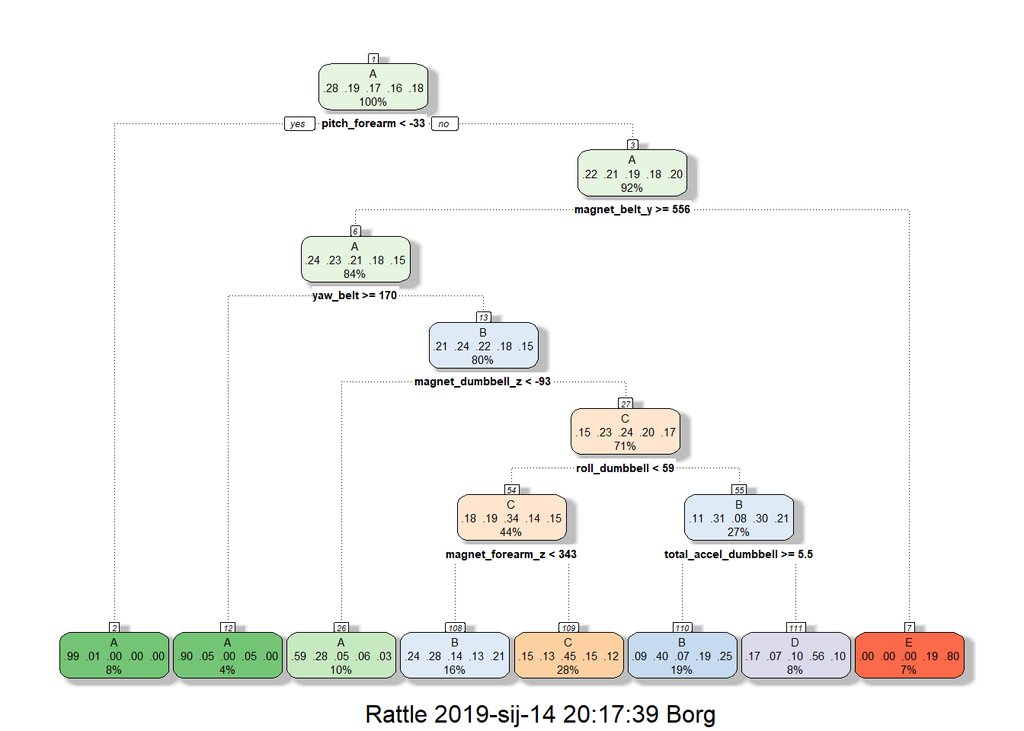

```r
library(caret)
set.seed(100003)
class.tree.model <- train(classe~., data=train.data, method="rpart", trControl=trControl)
fancyRpartPlot(class.tree.model$finalModel)
```

Then we validate the model build with classification tree alghoritm on the test set to find out how well it predicts “classe” variable outcome. We looking at the accuracy variable and confusion matrix.

```r
predict.class.tree.model <- predict(class.tree.model, newdata = test.data)
cm.class.tree.model <- confusionMatrix(test.data$classe, predict.class.tree.model)
cm.class.tree.model$table # confusion matrix
```

```
##           Reference
## Prediction   A   B   C   D   E
##          A 999 313 289  73   0
##          B 186 704 223  25   1
##          C  27 204 740  55   0
##          D  51 342 232 265  74
##          E  20 459 186  49 368
```

```r
cm.class.tree.model$overall # model accuracy
```

```
##       Accuracy          Kappa  AccuracyLower  AccuracyUpper   AccuracyNull
##   5.226848e-01   3.997360e-01   5.098299e-01   5.355172e-01   3.435854e-01
## AccuracyPValue  McnemarPValue
##  3.357223e-174  4.379711e-274
```

## Prediction with random forest

Second model is build with train() function from the caret package for “rf” model type.

```r
library(caret)
set.seed(100003)
rand.forest.model <- train(classe~., data=train.data, method="rf", trControl=trControl, verbose=FALSE)
print(rand.forest.model)
```

```
## Random Forest
##
## 13737 samples
##    31 predictor
##     5 classes: 'A', 'B', 'C', 'D', 'E'
##
## No pre-processing
## Resampling: Cross-Validated (5 fold)
## Summary of sample sizes: 10989, 10989, 10991, 10991, 10988
## Resampling results across tuning parameters:
##
##   mtry  Accuracy   Kappa
##    2    0.9900995  0.9874745
##   16    0.9887890  0.9858176
##   31    0.9763407  0.9700686
##
## Accuracy was used to select the optimal model using the largest value.
## The final value used for the model was mtry = 2.
```

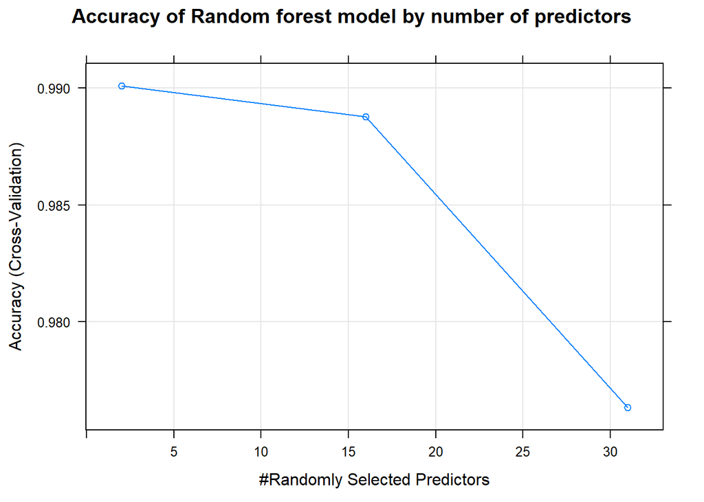

```r
plot(rand.forest.model,main="Accuracy of Random forest model by number of predictors")
```

```r
predict.rand.forest.model <- predict(rand.forest.model, newdata = test.data)
cm.rand.forest.model <- confusionMatrix(test.data$classe, predict.rand.forest.model )
cm.rand.forest.model$table # confusion matrix
```

```
##           Reference
## Prediction    A    B    C    D    E
##          A 1674    0    0    0    0
##          B   10 1128    1    0    0
##          C    0    7 1014    5    0
##          D    0    0   16  946    2
##          E    0    0    0    1 1081
```

```r
cm.rand.forest.model$overall # model accuracy
```

```
##       Accuracy          Kappa  AccuracyLower  AccuracyUpper   AccuracyNull
##      0.9928632      0.9909707      0.9903653      0.9948517      0.2861512
## AccuracyPValue  McnemarPValue
##      0.0000000            NaN
```

### Compute the variable importance

```r
most.imp.vars <- varImp(rand.forest.model)
most.imp.vars
```

```
## rf variable importance
##
##   only 20 most important variables shown (out of 31)
##
##                      Overall
## yaw_belt              100.00
## magnet_dumbbell_z      74.75
## magnet_belt_y          65.31
## pitch_forearm          60.11
## roll_forearm           55.76
## roll_dumbbell          53.71
## roll_arm               42.07
## gyros_belt_z           40.99
## total_accel_dumbbell   39.39
## accel_forearm_x        39.27
## yaw_dumbbell           37.91
## gyros_dumbbell_y       36.05
## pitch_dumbbell         32.32
## magnet_forearm_z       31.23
## magnet_arm_x           31.07
## magnet_forearm_y       29.10
## accel_forearm_z        28.98
## magnet_belt_x          28.86
## yaw_arm                27.30
## magnet_forearm_x       24.72
```

## Prediction with Generalized Boosted Regression Models

Third model is build with train function from the caret package for “gbm” model type.

```r
library(caret)
set.seed(100003)
gbm.model <- train(classe~., data=train.data, method="gbm", trControl=trControl, verbose=FALSE)
print(gbm.model)
```

```
## Stochastic Gradient Boosting
##
## 13737 samples
##    31 predictor
##     5 classes: 'A', 'B', 'C', 'D', 'E'
##
## No pre-processing
## Resampling: Cross-Validated (5 fold)
## Summary of sample sizes: 10989, 10989, 10991, 10991, 10988
## Resampling results across tuning parameters:
##
##   interaction.depth  n.trees  Accuracy   Kappa
##   1                   50      0.7176956  0.6421311
##   1                  100      0.7784807  0.7195902
##   1                  150      0.8118933  0.7619651
##   2                   50      0.8240507  0.7771828
##   2                  100      0.8769018  0.8442466
##   2                  150      0.9047819  0.8795292
##   3                   50      0.8660559  0.8304557
##   3                  100      0.9174490  0.8955411
##   3                  150      0.9413995  0.9258557
##
## Tuning parameter 'shrinkage' was held constant at a value of 0.1
##
## Tuning parameter 'n.minobsinnode' was held constant at a value of 10
## Accuracy was used to select the optimal model using the largest value.
## The final values used for the model were n.trees = 150,
##  interaction.depth = 3, shrinkage = 0.1 and n.minobsinnode = 10.
```

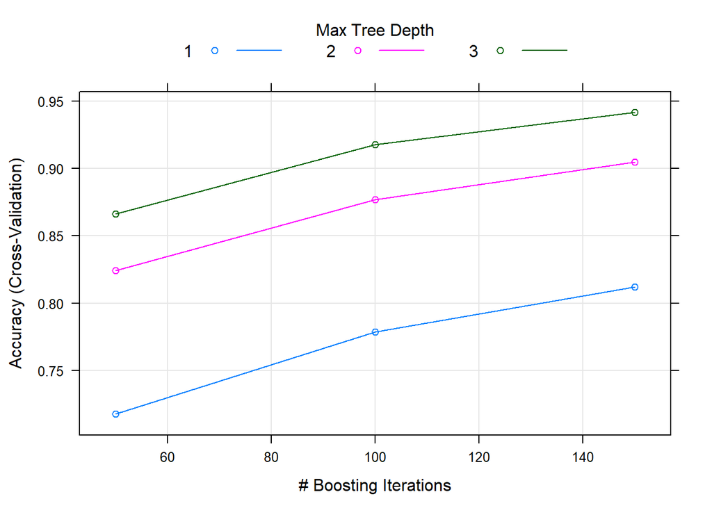

```r
plot(gbm.model)
```

```r
predict.gbm.model <- predict(gbm.model, newdata = test.data)
cm.gbm.model <- confusionMatrix(test.data$classe, predict.gbm.model)
cm.gbm.model$table # confusion matrix
```

```
##           Reference
## Prediction    A    B    C    D    E
##          A 1639   20    9    5    1
##          B   53 1041   40    1    4
##          C    0   44  960   21    1
##          D    4    8   37  912    3
##          E    5   13   10   18 1036
```

```r
cm.gbm.model$overall # model accuracy
```

```
##       Accuracy          Kappa  AccuracyLower  AccuracyUpper   AccuracyNull
##   9.495327e-01   9.361320e-01   9.436280e-01   9.549865e-01   2.890399e-01
## AccuracyPValue  McnemarPValue
##   0.000000e+00   4.338583e-09
```

The accuracy of the third “gradient boosting method” model is 95% which is very good, but random forest model is better.

# Conclusion

This shows that the random forest model is the best one with highest accuracy. I will apply the best model to the validation data and then use it to predict the values of classe for the test data set.

```r
validation.data <- test.raw
predict.final <- predict(rand.forest.model,newdata=validation.data)
predict.final
```

```
##  [1] B A B A A E D B A A B C B A E E A B B B
## Levels: A B C D E
```